[figure not shown]

**Picture this**: An urban landscape buzzing with `intelligent systems`, where every `CCTV feed`, every pixel, is more than just a picture—it's a treasure trove of information. A city that sees, understands, and responds. Sounds like science fiction? Well, it's closer than you think! Thanks to the groundbreaking advancements in `transformer models`, originally the superstar of natural language processing, this is our reality taking shape. Now, these models are storming the field of `computer vision`, `transforming object detection` and `semantic segmentation` with their unique abilities. Dive into this exciting journey with us as we unravel how these cutting-edge techniques are reshaping our urban environments into truly `Smart Cities`. It's more than just a technological revolution—it's a new chapter in enhancing `public safety` and `urban planning`. Get ready to be amazed!

# EXECUTIVE SUMMARY

The rapid evolution of urban spaces has prompted the need for advanced technologies to manage and enhance public safety and city planning, leading us to explore the potential of transformer models in computer vision tasks. Initially developed for natural language processing (NLP), transformers have demonstrated a significant potential for object detection and semantic segmentation.

However, conventional methods like Convolutional Neural Networks (CNNs) have been less successful in understanding the global context of an image, a crucial factor for these tasks. This shortcoming is particularly notable within the Smart Cities framework, where a comprehensive understanding of the scene is needed, such as recognizing clothing and color details.

`Transformer-based models` offer a solution to these challenges. Their `ability to handle long-range dependencies` within images can improve public safety using CCTV images within Smart Cities. These models can not only `detect individuals` but also `identify details` about them, such as `clothing` and `accessories`.

The application of this technology has substantial `business value`. It is especially useful in scenarios that require `locating missing persons` or `identifying suspects` in public safety incidents. Additionally, by `analyzing clothing patterns and colors` over time, it can anticipate potential issues or refine urban planning strategies proactively.

In conclusion, the use of `transformers` for `object detection` and `semantic segmentation` provides a powerful tool for overcoming existing challenges in computer vision and enhancing Smart City technologies. As research in this area progresses, we anticipate seeing more `innovative applications` and `accuracy improvements`, contributing to the creation of `safer` and `smarter` urban environments.

# MOTIVATION

As our urban landscapes continue to evolve, the need for advanced technologies to manage and enhance the `safety` and `efficiency` of these spaces becomes increasingly evident. One area of emerging potential lies in the application of `transformer models`, initially developed for natural language processing (NLP), to the field of computer vision. The ability of these models to analyze and interpret complex patterns within data can be harnessed to improve `public safety` and `city planning` within the `Smart City` framework.

# PROBLEM STATEMENT

Within the realm of Smart Cities, where a holistic comprehension of the scene is indispensable, encompassing facets like `attire` and `chromatic intricacies`, the present constraints impede endeavors to fortify `public safety` and `optimize urban planning` strategies. Consequently, an urgent imperative arises for cutting-edge methodologies, such as transformer models, that can redress these quandaries and furnish an all-encompassing perceptiveness of images within the Smart Cities framework. By leveraging the power of `transformer models`, which excel in capturing `global context` and `long-range dependencies`, it becomes possible to enhance object understanding and semantic segmentation in Smart City applications.

How can we `leverage transformer models` to `accurately identify` and `interpret objects` within images, considering the broader context of Smart Cities, including factors like clothing and color details, thereby enhancing `public safety` and `optimizing urban planning strategies`?

# METHODOLOGY

[figure not shown]

## Image Collection

Here, we need to incorporate the ability to select and process CCTV images. However, for this notebook, we will simply load a sample image.

- The code sets the cache directory for the `transformers` library.
- It imports necessary libraries, including classes for object detection and image processing from the `transformers` library.
- The code specifies the image to be processed and opens it using the Python Imaging Library (PIL).
- The pre-trained object detection model (`YolosForObjectDetection`) and image processor (`YolosImageProcessor`) are loaded.
- The image is processed by the `YolosImageProcessor` to create a tensor that is fed into the object detection model.
- The model generates outputs, including logits (raw, unnormalized output of the last layer of the model) and predicted bounding boxes for objects detected in the image.
- The object detection results are post-processed by applying a confidence threshold (0.9 in this case) and resizing the bounding boxes back to the original image size.
- Finally, the code prints the class, confidence score, and location (bounding box) of each detected object.

```python
# HTML code to toggle code cell visibility
from IPython.display import display, HTML
HTML('''<script src="https://cdnjs.cloudflare.com/ajax/libs/jquery/2.0.3/
jquery.min.js "></script><script>
code_show=true;
function code_toggle() {
if (code_show){
$('div.jp-CodeCell > div.jp-Cell-inputWrapper').hide();
} else {
$('div.jp-CodeCell > div.jp-Cell-inputWrapper').show();
}
code_show = !code_show
}
$( document ).ready(code_toggle);</script><form action="
javascript:code_toggle()"><input type="submit"
value="Click here to toggle on/off the raw code."></form>
''')
```

```python
import os
os.environ['XDG_CACHE_HOME'] = '/home/msds2023/fcamarao/.cache'

from transformers import YolosImageProcessor, YolosForObjectDetection
from PIL import Image
from IPython.display import display
import numpy as np
import torch
import requests
import matplotlib.pyplot as plt
import matplotlib.patches as patches
from transformers import (AutoFeatureExtractor,
                          SegformerForSemanticSegmentation)
import torch.nn as nn
import cv2



image_path = 'data/sample1.jpg'
main_image = Image.open(image_path)

model_person = YolosForObjectDetection.from_pretrained('hustvl/yolos-tiny')
image_processor = YolosImageProcessor.from_pretrained("hustvl/yolos-tiny")

inputs = image_processor(images=main_image, return_tensors="pt")
outputs = model_person(**inputs)

# model predicts bounding boxes and corresponding COCO classes
logits = outputs.logits
bboxes = outputs.pred_boxes

# print results
target_sizes = torch.tensor([main_image.size[::-1]])
results = image_processor.post_process_object_detection(
    outputs, threshold=0.9, target_sizes=target_sizes)[0]
for score, label, box in zip(results["scores"],
                             results["labels"], results["boxes"]):
    box = [round(i, 2) for i in box.tolist()]
    print(
        f"Detected {model_person.config.id2label[label.item()]} "
        f"with confidence "
        f"{round(score.item(), 3)} at location {box}"
    )
```

[output not shown]

```
Detected bus with confidence 0.972 at location [-0.05, 481.91, 334.05, 695.11]
Detected person with confidence 0.925 at location [770.99, 562.4, 844.47, 798.89]
Detected person with confidence 0.994 at location [1167.58, 567.19, 1302.29, 928.77]
Detected person with confidence 0.924 at location [537.46, 574.41, 598.23, 749.81]
Detected person with confidence 0.998 at location [823.27, 526.14, 1013.86, 1076.06]
Detected handbag with confidence 0.915 at location [1085.86, 635.89, 1179.23, 818.93]
Detected person with confidence 0.94 at location [213.45, 564.83, 288.41, 725.25]
Detected person with confidence 0.974 at location [352.56, 571.53, 439.53, 778.88]
Detected person with confidence 0.995 at location [652.65, 535.07, 775.74, 870.54]
Detected person with confidence 0.985 at location [471.23, 568.19, 565.09, 788.3]
Detected traffic light with confidence 0.91 at location [1055.61, 458.58, 1084.79, 512.21]
Detected person with confidence 0.99 at location [1734.53, 558.08, 1870.82, 852.69]
Detected person with confidence 0.966 at location [1833.91, 555.89, 1919.91, 904.1]
Detected person with confidence 0.995 at location [1512.17, 551.7, 1637.86, 865.33]
Detected traffic light with confidence 0.955 at location [967.74, 485.35, 991.58, 517.58]
```

## Object Detection

Now, I have applied object detection to filter the image and only display the bounding boxes around the detected "person" class labels.

- The code creates a figure and axes for displaying the image using matplotlib.
- It displays the original image on the created axes.
- An empty list is initialized to store bounding box values.
- The code iterates through the object detection results (scores, labels, boxes). For each detected object:
  - If the label of the detected object is 'person', the code processes the bounding box.
  - The bounding box's coordinates are rounded to two decimal places and printed, along with the object's label and the confidence score.
  - These bounding box values are stored in the list.
  - The color for the bounding box is set to red.
  - A rectangular patch is created with the bounding box dimensions and color, representing the detected person in the image.
  - This patch is added to the axes.
- Finally, the updated figure, with bounding boxes for detected persons, is displayed.

```python
# Create figure and axes
fig, ax = plt.subplots(figsize=(12, 6))

# Display the image
ax.imshow(main_image)

bounding_boxes = []  # List to store bounding box values

# Create bounding boxes
for score, label, box in zip(results["scores"],
                             results["labels"], results["boxes"]):
    # Get the label name
    label_name = model_person.config.id2label[label.item()]
    # Only process the bounding boxes for 'person'
    if label_name == 'person':
        box = [round(i, 2) for i in box.tolist()]
        print(
            f"Detected {label_name} with confidence "
            f"{round(score.item(), 3)} at location {box}"
        )
        # Store bounding box values in the list
        bounding_boxes.append(box)

        # Set default color for bounding box and count label
        bbox_color = 'red'

        # Create a Rectangle patch with the modified color
        rect = patches.Rectangle((box[0], box[1]), box[2]-box[0], box[3] -
                                 box[1], linewidth=1,
                                 edgecolor=bbox_color, facecolor='none')
        # Add the patch to the Axes
        ax.add_patch(rect)
plt.savefig('data/bounding_box.png')
plt.close()

# # Display the updated figure
# plt.show()

html_code = """
<div style="display: flex; justify-content: center;">
    <img src="data/bounding_box.png">
</div>
"""
display(HTML(html_code))
```

```
Detected person with confidence 0.925 at location [770.99, 562.4, 844.47, 798.89]
Detected person with confidence 0.994 at location [1167.58, 567.19, 1302.29, 928.77]
Detected person with confidence 0.924 at location [537.46, 574.41, 598.23, 749.81]
Detected person with confidence 0.998 at location [823.27, 526.14, 1013.86, 1076.06]
Detected person with confidence 0.94 at location [213.45, 564.83, 288.41, 725.25]
Detected person with confidence 0.974 at location [352.56, 571.53, 439.53, 778.88]
Detected person with confidence 0.995 at location [652.65, 535.07, 775.74, 870.54]
Detected person with confidence 0.985 at location [471.23, 568.19, 565.09, 788.3]
Detected person with confidence 0.99 at location [1734.53, 558.08, 1870.82, 852.69]
Detected person with confidence 0.966 at location [1833.91, 555.89, 1919.91, 904.1]
Detected person with confidence 0.995 at location [1512.17, 551.7, 1637.86, 865.33]
```

[figure not shown]

### Cropped Bounding Boxed Images

Using the `bounding boxes` obtained from the object detection model, I will proceed to crop the image based on these boxes. The cropped images will then be stored for further use in the semantic segmentation process.

```python
filename = os.path.splitext(os.path.basename(image_path))[0]
# Crop and save the bounding boxes as separate images
for i, box in enumerate(bounding_boxes):
    # Convert box values to integers
    box = [int(coord) for coord in box]

    # Crop the image using the bounding box coordinates
    cropped_image = main_image.crop(box)

    # Save the cropped image with a unique filename
    cropped_image.save(f"data/cropped_images/{filename}_{i}.jpg")
```

## Semantic Segmentation

In this case, I have applied semantic segmentation to identify specific objects segmented from the person. I then utilized masking to isolate these objects within the image.

- The code loads a feature extractor and a semantic segmentation model using the `AutoFeatureExtractor` and `SegformerForSemanticSegmentation` classes from the transformers library.
- It defines a dictionary mapping class indices to labels for different parts of a person's clothing and accessories.
- The path to the directory containing the cropped images of detected persons is specified.
- The code lists all the image files in the directory that correspond to a particular person (identified by a filename prefix).
- For each cropped image of the person:
  - The image is opened and processed by the feature extractor to create a tensor.
  - This tensor is fed into the semantic segmentation model, which generates logits (raw, unnormalized output of the last layer of the model).
  - The logits are upsampled to match the original image size, and the class with the maximum logit value for each pixel is considered as the predicted class.
  - The original image and the predicted segmentation mask are displayed side by side.
  - The predicted segmentation mask is converted to a numpy array, and the unique classes present in the mask are identified along with their counts.
  - The logits are upsampled again to a fixed size (128x128), and the softmax function is applied to compute probabilities for each class.
  - The class with the maximum probability for each pixel is considered as the predicted class, and the corresponding probability values are extracted.
  - The average probability (confidence) for each unique class present in the segmentation mask is computed and printed.

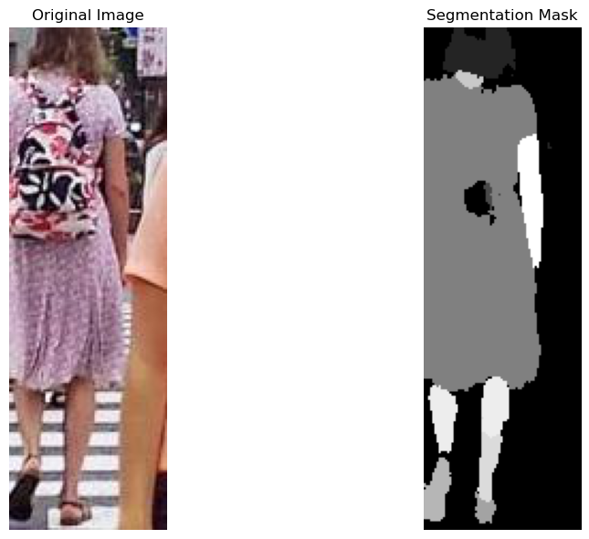

```
Average confidence for Background: 0.931
Average confidence for Hair: 0.750
Average confidence for Sunglasses: 0.487
Average confidence for Upper-clothes: 0.426
Average confidence for Dress: 0.880
Average confidence for Left-shoe: 0.625
Average confidence for Right-shoe: 0.733
Average confidence for Face: 0.548
Average confidence for Left-leg: 0.713
Average confidence for Right-leg: 0.702
Average confidence for Left-arm: 0.858
```

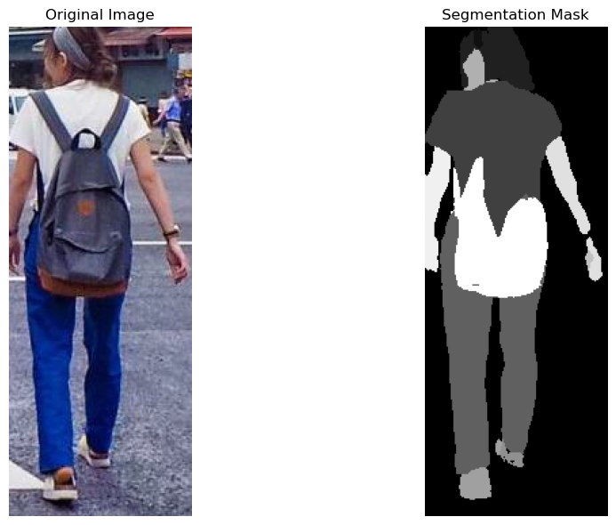

```
Average confidence for Background: 0.966
Average confidence for Hat: 0.496
Average confidence for Hair: 0.810
Average confidence for Upper-clothes: 0.883
Average confidence for Pants: 0.958
Average confidence for Left-shoe: 0.565
Average confidence for Right-shoe: 0.595
Average confidence for Face: 0.789
Average confidence for Left-leg: 0.438
Average confidence for Left-arm: 0.796
Average confidence for Right-arm: 0.818
Average confidence for Bag: 0.840
```

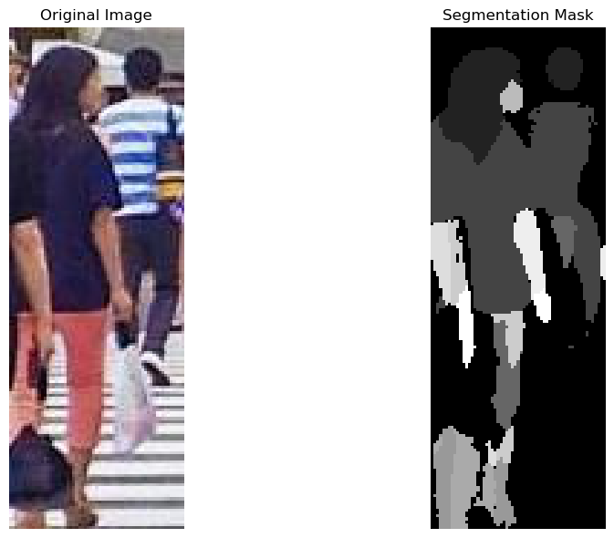

```
Average confidence for Background: 0.845
Average confidence for Hat: 0.356
Average confidence for Hair: 0.800
Average confidence for Upper-clothes: 0.809
Average confidence for Pants: 0.500
Average confidence for Left-shoe: 0.522
Average confidence for Right-shoe: 0.570
Average confidence for Face: 0.663
Average confidence for Left-leg: 0.549
Average confidence for Right-leg: 0.612
Average confidence for Left-arm: 0.766
Average confidence for Right-arm: 0.672
```

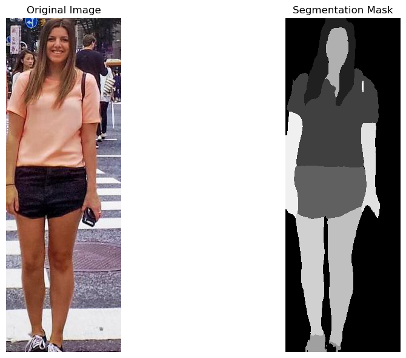

```
Average confidence for Background: 0.981
Average confidence for Hair: 0.878
Average confidence for Upper-clothes: 0.949
Average confidence for Pants: 0.972
Average confidence for Left-shoe: 0.649
Average confidence for Right-shoe: 0.837
Average confidence for Face: 0.916
Average confidence for Left-leg: 0.974
Average confidence for Right-leg: 0.974
Average confidence for Left-arm: 0.907
Average confidence for Right-arm: 0.910
Average confidence for Bag: 0.579
```

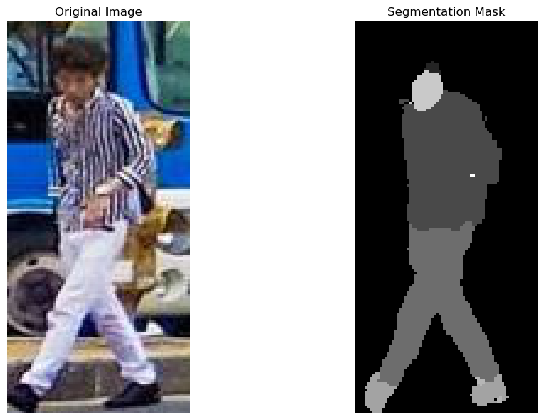

```
Average confidence for Background: 0.970
Average confidence for Hair: 0.553
Average confidence for Upper-clothes: 0.897
Average confidence for Pants: 0.942
Average confidence for Left-shoe: 0.559
Average confidence for Right-shoe: 0.385
Average confidence for Face: 0.741
Average confidence for Left-arm: 0.467
```

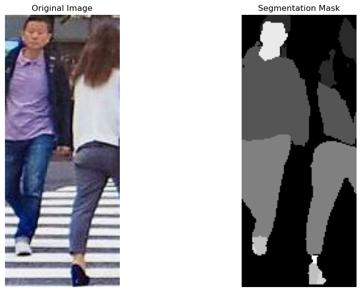

```
Average confidence for Background: 0.914
Average confidence for Hair: 0.693
Average confidence for Upper-clothes: 0.886
Average confidence for Pants: 0.952
Average confidence for Left-shoe: 0.621
Average confidence for Right-shoe: 0.466
Average confidence for Face: 0.902
Average confidence for Left-leg: 0.367
```

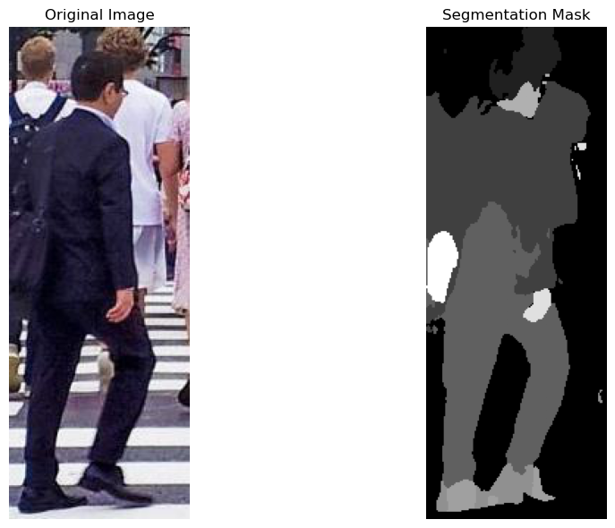

```
Average confidence for Background: 0.926
Average confidence for Hair: 0.740
Average confidence for Upper-clothes: 0.860
Average confidence for Pants: 0.857
Average confidence for Left-shoe: 0.625
Average confidence for Right-shoe: 0.615
Average confidence for Face: 0.816
Average confidence for Left-arm: 0.769
Average confidence for Bag: 0.526
```

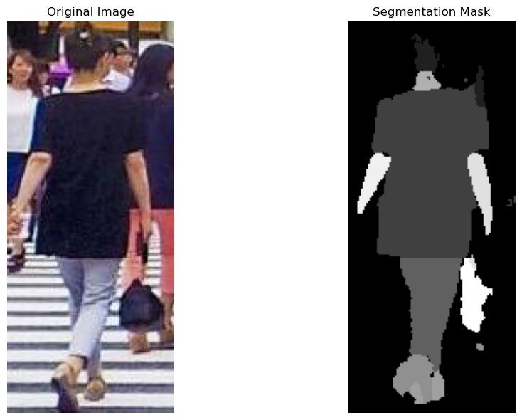

```
Average confidence for Background: 0.914
Average confidence for Hair: 0.601
Average confidence for Upper-clothes: 0.941
Average confidence for Pants: 0.903
Average confidence for Left-shoe: 0.574
Average confidence for Right-shoe: 0.610
Average confidence for Face: 0.577
Average confidence for Left-arm: 0.781
Average confidence for Right-arm: 0.720
Average confidence for Bag: 0.716
```

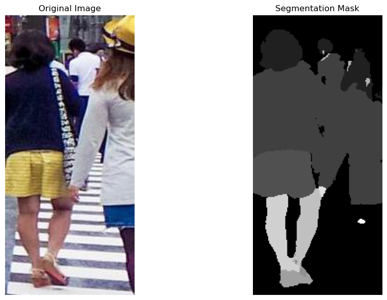

```
Average confidence for Background: 0.928
Average confidence for Hair: 0.791
Average confidence for Upper-clothes: 0.910
Average confidence for Skirt: 0.963
Average confidence for Left-shoe: 0.390
Average confidence for Right-shoe: 0.553
Average confidence for Face: 0.495
Average confidence for Left-leg: 0.866
Average confidence for Right-leg: 0.883
Average confidence for Left-arm: 0.471
Average confidence for Bag: 0.564
```

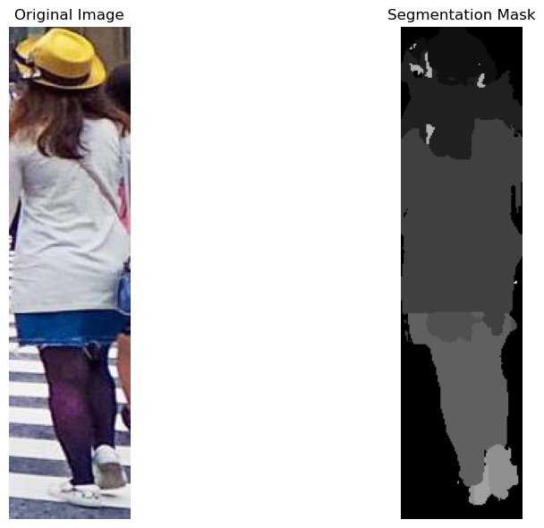

```
Average confidence for Background: 0.866
Average confidence for Hat: 0.832
Average confidence for Hair: 0.817
Average confidence for Upper-clothes: 0.941
Average confidence for Skirt: 0.599
Average confidence for Pants: 0.894
Average confidence for Left-shoe: 0.578
Average confidence for Right-shoe: 0.532
Average confidence for Face: 0.529
Average confidence for Bag: 0.365
```

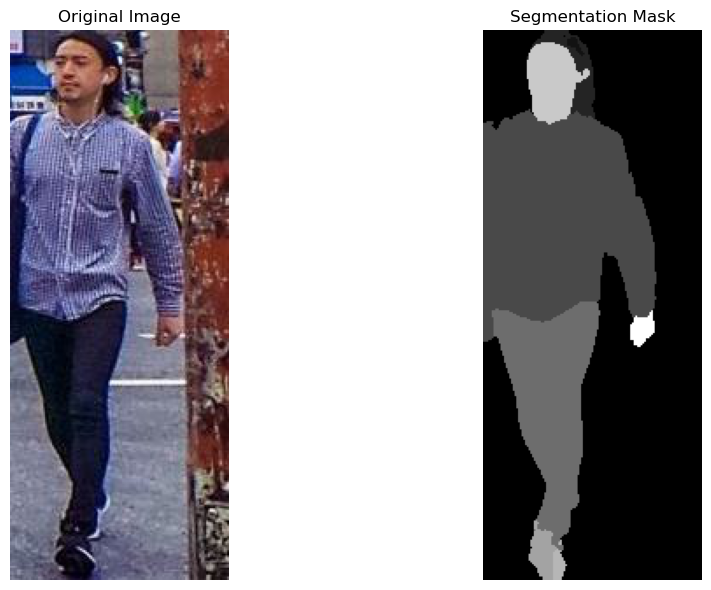

```
Average confidence for Background: 0.985
Average confidence for Hat: 0.575
Average confidence for Hair: 0.713
Average confidence for Upper-clothes: 0.958
Average confidence for Pants: 0.964
Average confidence for Left-shoe: 0.655
Average confidence for Right-shoe: 0.506
Average confidence for Face: 0.912
Average confidence for Left-arm: 0.666
```

```python
# Load the feature extractor and segmentation model
extractor = AutoFeatureExtractor.from_pretrained(
    "mattmdjaga/segformer_b2_clothes")
model_segment = SegformerForSemanticSegmentation.from_pretrained(
    "mattmdjaga/segformer_b2_clothes")

# Map of class indices to labels
id2label = {
    0: "Background",
    1: "Hat",
    2: "Hair",
    3: "Sunglasses",
    4: "Upper-clothes",
    5: "Skirt",
    6: "Pants",
    7: "Dress",
    8: "Belt",
    9: "Left-shoe",
    10: "Right-shoe",
    11: "Face",
    12: "Left-leg",
    13: "Right-leg",
    14: "Left-arm",
    15: "Right-arm",
    16: "Bag",
    17: "Scarf",
}

# Define the directory path containing the images
image_path_2 = "data/cropped_images"

# Specify the prefix
prefix = filename + "_"

# Get the list of image files in the directory
image_files = [file for file in os.listdir(
    image_path_2) if file.startswith(prefix)]

# Iterate over each image file in the directory
for file_name in image_files:
    file_path = os.path.join(image_path_2, file_name)
    image = Image.open(file_path)  # Load the image

    # Process the image
    inputs = extractor(images=image, return_tensors="pt")

    outputs = model_segment(**inputs)
    logits = outputs.logits.cpu()

    upsampled_logits = nn.functional.interpolate(
        logits,
        size=image.size[::-1],
        mode="bilinear",
        align_corners=False,
    )

    pred_seg = upsampled_logits.argmax(dim=1)[0]

    # Display the image and the predicted segmentation mask
    fig, axes = plt.subplots(1, 2, figsize=(12, 6))

    # Display the original image
    axes[0].imshow(image)
    axes[0].set_title("Original Image")
    axes[0].axis("off")

    # Display the predicted segmentation mask
    axes[1].imshow(pred_seg, cmap="gray")
    axes[1].set_title("Segmentation Mask")
    axes[1].axis("off")

    plt.tight_layout()
    plt.show()

    # Convert to numpy array
    pred_seg_np = pred_seg.detach().numpy()

    # Count unique class indices
    unique, counts = np.unique(pred_seg_np, return_counts=True)

    upsampled_logits = nn.functional.interpolate(
        logits,
        size=(128, 128),  # Set the size directly
        mode="bilinear",
        align_corners=False,
    )

    # Compute softmax probabilities
    softmax_logits = torch.nn.functional.softmax(upsampled_logits, dim=1)

    # Get the probabilities of the predicted classes
    probabilities = softmax_logits.max(dim=1).values.squeeze()

    # Convert to numpy array
    probabilities_np = probabilities.detach().numpy()

    # Get the segmentation prediction
    pred_seg = upsampled_logits.argmax(dim=1)

    # Convert to numpy array
    pred_seg_np = pred_seg.squeeze().detach().numpy()

    # Print average probability (confidence) for each class
    for u in np.unique(pred_seg_np):
        average_probability = probabilities_np[pred_seg_np == u].mean()
        print(
            f"Average confidence for "
            f"{id2label[u]}: {average_probability:.3f}")
```

## Color Image Segmentation

For this section, I have applied color image segmentation to filter the colors of the selected objects and perform further classification on them.

### Color Thresholds

```python
import matplotlib.patches as patches
color_thresholds = {
    'red': (np.array([0, 50, 50]), np.array([15, 255, 255])),
    'orange': (np.array([15, 50, 50]), np.array([45, 255, 255])),
    'yellow': (np.array([25, 50, 50]), np.array([60, 255, 255])),
    'green': (np.array([60, 50, 50]), np.array([150, 255, 255])),
    'blue': (np.array([150, 50, 50]), np.array([225, 255, 255])),
    'purple': (np.array([225, 50, 50]), np.array([300, 255, 255])),
    'pink': (np.array([300, 50, 50]), np.array([360, 255, 255])),
    'black': (np.array([0, 0, 0]), np.array([180, 255, 50])),
    'white': (np.array([0, 0, 200]), np.array([180, 50, 255])),
}


fig, ax = plt.subplots(1, 1, figsize=(12, 6),
                       dpi=80, facecolor='w', edgecolor='k')

# we will normalize our threshold data to match to colormap
norm = plt.Normalize(vmin=0, vmax=360)

# Using a sample colormap for display
cmap = plt.get_cmap('hsv')

for sp in ax.spines.values():
    sp.set_visible(False)

for idx, (color, (lower, upper)) in enumerate(color_thresholds.items()):
    ax.add_patch(patches.Rectangle((lower[0], 0), upper[0]-lower[0], 10,
                                   facecolor=cmap(norm((lower[0]+upper[0])/2)),
                                   label=color))

plt.xlim([0, 360])
plt.ylim([0, 10])
plt.yticks([])
plt.xticks(list(range(0, 361, 30)))
plt.legend(loc='upper center', bbox_to_anchor=(0.5, -0.05),
           fancybox=True, shadow=True, ncol=7)

# Save the plot as an image file
plt.savefig('data/color_thresholds_plot1.png')

# Close the current figure
plt.close()

html_code = """
<div style="display: flex; justify-content: center;">
    <img src="data/color_thresholds_plot.png">
</div>
"""
display(HTML(html_code))
```

[figure not shown]

### Object and Color Segmentation Classification

- The code specifies certain parameters like the target label ("Upper-clothes"), the average probability threshold (0.6), the required percentage (15%), and the target color ("red").
- It then initializes an empty list `outputted_images` to store the file names of the images that meet the specified conditions.
- For each image in the directory:
  - The image is loaded and processed using the feature extractor and segmentation model.
  - The softmax probabilities of the predicted classes are computed.
  - The segmentation prediction is obtained by finding the class with the maximum probability for each pixel in the image.
  - The code then checks if the average probability of the target label is greater than the specified probability threshold.
  - If the condition is met, the code creates a mask for the target label using the `cv2.inRange` function. This function checks if array elements lie between the elements of two other arrays (in this case, the lower and upper range of the target color in the HSV color space).
  - The original image is then converted to HSV color space using the `cv2.cvtColor` function.
  - The color mask is applied to the target label region of the segmentation mask.
  - The code then checks if the color-filtered region constitutes a certain percentage of the total region of the target label. - If it does, the original image, the target label, and the color filtered segmentation mask are displayed, and the file name of the image is added to the `outputted_images` list.
- After all images have been processed, the code extracts the numeric values from the file names in the `utputted_images` list and stores them in a separate list `numeric_values`.

```python
# Specify the label and average probability threshold
target_label = "Upper-clothes"
probability_threshold = 0.6
required_percentage = 15  # 10%

# Specify the target color
target_color = "red"

# List to store the file names of outputted images
outputted_images = []

# Iterate over each image file in the directory
for file_name in image_files:
    file_path = os.path.join(image_path_2, file_name)
    image = Image.open(file_path)  # Load the image

    # Process the image
    inputs = extractor(images=image, return_tensors="pt")

    outputs = model_segment(**inputs)
    logits = outputs.logits.cpu()

    upsampled_logits = nn.functional.interpolate(
        logits,
        size=image.size[::-1],
        mode="bilinear",
        align_corners=False,
    )

    # Compute softmax probabilities
    softmax_logits = torch.nn.functional.softmax(upsampled_logits, dim=1)

    # Get the probabilities of the predicted classes
    probabilities = softmax_logits.max(dim=1).values.squeeze()

    # Convert to numpy array
    probabilities_np = probabilities.detach().cpu().numpy()

    # Get the segmentation prediction
    pred_seg = upsampled_logits.argmax(dim=1)

    # Convert to numpy array
    pred_seg_np = pred_seg.squeeze().detach().cpu().numpy()

    # Filter image based on label and average probability threshold
    label_index = list(id2label.values()).index(target_label)
    average_probability = probabilities_np[pred_seg_np == label_index].mean()

    if average_probability > probability_threshold:
        # Convert pred_seg_np to uint8 for imshow()
        pred_seg_np = pred_seg_np.astype(np.uint8)

        # Convert the original image to HSV
        image_hsv = cv2.cvtColor(np.array(image), cv2.COLOR_RGB2HSV)

        # Apply the color threshold to the image
        lower, upper = color_thresholds[target_color]
        mask = cv2.inRange(image_hsv, lower, upper)

        # Apply the mask to the target label region of the segmentation mask
        color_mask = np.zeros_like(pred_seg_np)
        color_mask[pred_seg_np ==
                   label_index] = mask[pred_seg_np == label_index]

        # Check if the color-filtered region constitutes a
        # certain percentage of the total region of the target label
        color_mask_percentage = np.sum(
            color_mask) / np.sum(pred_seg_np == label_index)

        if color_mask_percentage > required_percentage:
            # Display the original image, target label,
            # and the color filtered segmentation mask
            fig, ax = plt.subplots(1, 3, figsize=(12, 6))

            ax[0].imshow(image)
            ax[0].set_title('Original Image')
            ax[0].axis('off')

            ax[1].imshow(pred_seg_np)
            ax[1].set_title(f'{target_label} Segmentation')
            ax[1].axis('off')

            ax[2].imshow(color_mask)
            ax[2].set_title(
                f'{target_label} Segmentation Mask ({target_color})')
            ax[2].axis('off')

            plt.tight_layout()
            # Save the plot as an image file
            plt.savefig('data/segmentation.png')
            plt.close()



            # Append the file name to the list
            outputted_images.append(file_name)

numeric_values = []

for image_name in outputted_images:
    numeric_value = image_name.split("_")[1].split(".")[0]
    numeric_values.append(int(numeric_value))


html_code = """
<div style="display: flex; justify-content: center;">
    <img src="data/segmentation.png">
</div>
"""
display(HTML(html_code))
```

[figure not shown]

## Object (Person) Classification

Finally, using the results from the previous steps, I am able to successfully classify the person based on the specified parameters, such as the target label for object filtering, color filtering, and threshold. As a final step, I apply bounding boxes to the original photo to highlight the classified person.

- The main image is displayed.
- The code then iterates over each bounding box and its index from the `bounding_boxes list`:
  - If the index is included in the `numeric_values` list, the code proceeds to process the bounding box.
  - The bounding box values are converted to integers.
  - The positions of the label (x and y coordinates) are calculated based on the bounding box values. If the y coordinate is less than 0, it's set to 0 to ensure the label isn't drawn outside the image.
  - A label text is created, containing the target label and target color, and is displayed using matplotlib.pyplot.text. A box is drawn around the label text, using the bbox property to specify its style, face color (red), and transparency (alpha).
  - A rectangle is drawn around the bounding box using `matplotlib.patches.Rectangle`, with a line width of 3, edge color of green, and no fill color. This rectangle is then added to the axes using `matplotlib.axes.Axes.add_patch`.
- The axes are then turned off using matplotlib.axes.Axes.axis('off') to ensure a clean image display without any axis lines or labels.
- The layout is adjusted using matplotlib.pyplot.tight_layout to ensure the subplots do not overlap.
- The updated image is then displayed.

```python
# Create figure and axes with full width
fig, ax = plt.subplots(figsize=(12, 6))

# Display the image
ax.imshow(main_image)

for i, box in enumerate(bounding_boxes):
    if i in numeric_values:
        # Convert box values to integers
        box = [int(coord) for coord in box]

        # Calculate label position
        label_x = box[0]
        label_y = box[1] - 10
        if label_y < 0:
            label_y = 0

        # Add a text label to the box with background color and transparency
        label_text = f"{target_label} : {target_color}"
        bbox_props = dict(boxstyle='square,pad=0.1',
                          facecolor='red', alpha=0.5)
        plt.text(label_x, label_y, label_text,
                 color='white', fontsize=15, bbox=bbox_props)

        specific_bbox_color = 'green'
        specific_rect = patches.Rectangle(
            (box[0], box[1]), box[2]-box[0], box[3]-box[1],
            linewidth=3, edgecolor=specific_bbox_color, facecolor='none')
        ax.add_patch(specific_rect)

# Remove axis
ax.axis('off')
plt.tight_layout()

# Save the plot as an image file
plt.savefig('data/output.png')

# Close the plot
plt.close()

# # Display the updated figure
# plt.show()

html_code = """
<div style="display: flex; justify-content: center;">
    <img src="data/output.png">
</div>
"""
display(HTML(html_code))
```

[figure not shown]

# CONCLUSION

Harnessing the power of technology to revolutionize safety and efficiency, the capability to `accurately detect and identify individuals` based on their clothing and color information is nothing short of ground-breaking. This isn't just a game-changer, it's a life-changer.

Imagine the profound potential in scenarios such as `locating a missing person` or `identifying a suspect` in public safety incidents. Picture law enforcement and investigative teams armed with this potent tool, being able to extract crucial insights from what may seem like inconspicuous details. This technology isn't just assisting, it's leading the charge in investigations.

But the magic doesn't stop there. This technology goes beyond reactive measures, it's about `enhancing public safety` proactively. It's about predicting patterns in clothing colors and types over time to preempt potential crowd-related issues or to refine urban planning strategies. This isn't just technology, it's foresight.

At the heart of this transformative power are `transformers used for object detection and semantic segmentation`. They are not just tools, they are the backbone of Smart City technologies. They allow us to delve deeper into our understanding of urban environments, empowering us to make strides in improving public safety and city planning.

As we push the boundaries of this exciting field, we expect to see even more `innovative applications and improved accuracy`. We are not just making our cities smarter, we are making them safer, more efficient and more livable. This is more than just an advancement in technology, it's a leap towards a brighter future.

# REFERENCES

You can find the github repository https://github.com/flcamarao/Transformers-Object-Detection-and-Semantics-Segmentation.git and other projects https://flcamarao.github.io/

Hugging Face. (n.d.). YolosForObjectDetection. Retrieved from [URL: https://huggingface.co/hustvl/yolos-tiny]

Hugging Face. (n.d.). SegformerForSemanticSegmentation. Retrieved from [URL: https://huggingface.co/mattmdjaga/segformer_b2_clothes]

OpenAI. (n.d.). Conversations. Retrieved from [URL: https://chat.openai.com/]

Shibuya Crossing. Retrieved from [URL: https://4.bp.blogspot.com/-eImJW3p_YTM/Wg5OKtBi87I/AAAAAAAAUrg/WNTANuRanSofJAbBIqh71bY4uGQ8VY0jgCLcBGAs/s1600/IMG_9271.jpg]